# Prediction Assignment Writeup, Course: Practical Machine Learning by John Hopkins university

Sören Nonnengart

2022-08-24

## Introduction

Here you see the results of my final Coursera’s Practical Machine Learning course, as part of the Data Science Specialization track offered by John Hopkins with coursera.

In this project, I will use data from accelerometers on the belt, forearm, arm, and dumbell of 6 participants to predict the manner in which they did the exercise. This is the “classe” variable in the training set.

I will train 4 models overall:

- Decision Trees
- Random Forest
- Gradient Boosted Trees
- Support Vector Machine using k-folds cross validation on the training set.

I then predict using a validation set randomly selected from the training csv data to obtain the accuracy and out of sample error rate. Based on those numbers, I decide on the best model, and use it to predict 20 cases using the test csv set.

## Loading Data and Libraries

#### Libraries that will to be used for the analysis

```r
library(caret)
library(kernlab)
library(rattle)
library(lattice)
library(ggplot2)
library(corrplot)
```

### set seed

```r
set.seed(318925)
```

### load the training and testdatasets

```
## [1] "/Users/sorennonnengart/Coursera/Data_science/tasks/course_8_Machine learning"
```

```r
traincsv <- read.csv("pml-training.csv")
testcsv <- read.csv("pml-testing.csv")
```

```r
dim(traincsv)
```

```
## [1] 19622   160
```

```r
dim(testcsv)
```

```
## [1]  20 160
```

#### You can see that there are 160 variables and 19622 observations in the training set and 20 for the test dataset.

## Cleaning the Data

#### Removing NA’s in the variables

```r
traincsv <- traincsv[,colMeans(is.na(traincsv)) < .9]
traincsv <- traincsv[,-c(1:7)]
```

#### Removing near zero variance variables.

```r
nvz <- nearZeroVar(traincsv)
traincsv <- traincsv[,-nvz]
dim(traincsv)
```

```
## [1] 19622    53
```

#### The removing of the unnecessary variables are finished, so now the training dataset can be split into a validation and sub training set. The testing set “testcsv” will be left alone, and used for the final quiz test cases.

```r
inTrain <- createDataPartition(y=traincsv$classe, p=0.7, list=F)
train <- traincsv[inTrain,]
valid <- traincsv[-inTrain,]
```

## Now create and test the models

```r
control <- trainControl(method="cv", number=3, verboseIter=F)
```

## Decision Tree

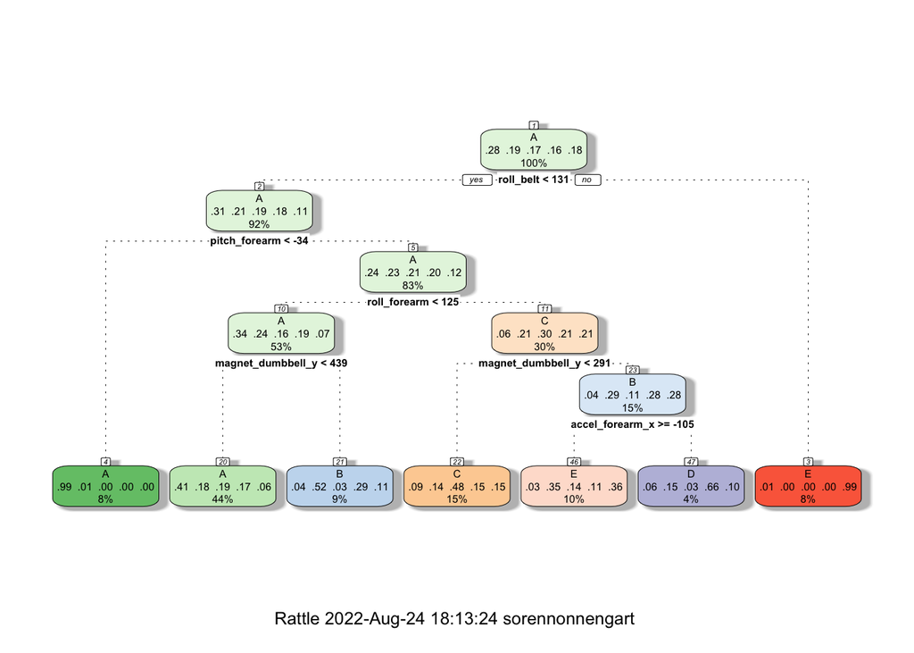

```r
mod_trees <- train(classe~., data=train, method="rpart", trControl = control, tuneLength = 5)
fancyRpartPlot(mod_trees$finalModel)
```

```r
pred_trees <- predict(mod_trees, valid)
cmtrees <- confusionMatrix(pred_trees, factor(valid$classe))
cmtrees
```

```
## Confusion Matrix and Statistics
##
##           Reference
## Prediction    A    B    C    D    E
##          A 1500  468  461  447  161
##          B   29  303   16  178   73
##          C   95  103  471  121  124
##          D   17   42   10  158   33
##          E   33  223   68   60  691
##
## Overall Statistics
##
##                Accuracy : 0.5307
##                  95% CI : (0.5178, 0.5435)
##     No Information Rate : 0.2845
##     P-Value [Acc > NIR] : < 2.2e-16
##
##                   Kappa : 0.387
##
##  Mcnemar's Test P-Value : < 2.2e-16
##
## Statistics by Class:
##
##                      Class: A Class: B Class: C Class: D Class: E
## Sensitivity            0.8961  0.26602  0.45906  0.16390   0.6386
## Specificity            0.6350  0.93763  0.90883  0.97927   0.9200
## Pos Pred Value         0.4939  0.50584  0.51532  0.60769   0.6428
## Neg Pred Value         0.9389  0.84185  0.88835  0.85671   0.9187
## Prevalence             0.2845  0.19354  0.17434  0.16381   0.1839
## Detection Rate         0.2549  0.05149  0.08003  0.02685   0.1174
## Detection Prevalence   0.5161  0.10178  0.15531  0.04418   0.1827
## Balanced Accuracy      0.7655  0.60183  0.68395  0.57159   0.7793
```

## Random Forest

```r
mod_rf <- train(classe~., data=train, method="rf", trControl = control, tuneLength = 5)
pred_rf <- predict(mod_rf, valid)
cmrf <- confusionMatrix(pred_rf, factor(valid$classe))
cmrf
```

```
## Confusion Matrix and Statistics
##
##           Reference
## Prediction    A    B    C    D    E
##          A 1667    8    0    0    0
##          B    4 1131    3    0    0
##          C    3    0 1022    8    0
##          D    0    0    1  956    1
##          E    0    0    0    0 1081
##
## Overall Statistics
##
##                Accuracy : 0.9952
##                  95% CI : (0.9931, 0.9968)
##     No Information Rate : 0.2845
##     P-Value [Acc > NIR] : < 2.2e-16
##
##                   Kappa : 0.994
##
##  Mcnemar's Test P-Value : NA
##
## Statistics by Class:
##
##                      Class: A Class: B Class: C Class: D Class: E
## Sensitivity            0.9958   0.9930   0.9961   0.9917   0.9991
## Specificity            0.9981   0.9985   0.9977   0.9996   1.0000
## Pos Pred Value         0.9952   0.9938   0.9894   0.9979   1.0000
## Neg Pred Value         0.9983   0.9983   0.9992   0.9984   0.9998
## Prevalence             0.2845   0.1935   0.1743   0.1638   0.1839
## Detection Rate         0.2833   0.1922   0.1737   0.1624   0.1837
## Detection Prevalence   0.2846   0.1934   0.1755   0.1628   0.1837
## Balanced Accuracy      0.9970   0.9958   0.9969   0.9956   0.9995
```

## Gradient Boosted Trees

```r
mod_gbm <- train(classe~., data=train, method="gbm", trControl = control, tuneLength = 5, verbose = F)
pred_gbm <- predict(mod_gbm, valid)
cmgbm <- confusionMatrix(pred_gbm, factor(valid$classe))
cmgbm
```

```
## Confusion Matrix and Statistics
##
##           Reference
## Prediction    A    B    C    D    E
##          A 1665   11    0    0    2
##          B    5 1122    9    0    1
##          C    4    6 1009   13    3
##          D    0    0    6  950    1
##          E    0    0    2    1 1075
##
## Overall Statistics
##
##                Accuracy : 0.9891
##                  95% CI : (0.9861, 0.9916)
##     No Information Rate : 0.2845
##     P-Value [Acc > NIR] : < 2.2e-16
##
##                   Kappa : 0.9862
##
##  Mcnemar's Test P-Value : NA
##
## Statistics by Class:
##
##                      Class: A Class: B Class: C Class: D Class: E
## Sensitivity            0.9946   0.9851   0.9834   0.9855   0.9935
## Specificity            0.9969   0.9968   0.9946   0.9986   0.9994
## Pos Pred Value         0.9923   0.9868   0.9749   0.9927   0.9972
## Neg Pred Value         0.9979   0.9964   0.9965   0.9972   0.9985
## Prevalence             0.2845   0.1935   0.1743   0.1638   0.1839
## Detection Rate         0.2829   0.1907   0.1715   0.1614   0.1827
## Detection Prevalence   0.2851   0.1932   0.1759   0.1626   0.1832
## Balanced Accuracy      0.9958   0.9910   0.9890   0.9920   0.9965
```

## Support Vector Machines

```r
mod_svm <- train(classe~., data=train, method="svmLinear", trControl = control, tuneLength = 5, verbose = F)
pred_svm <- predict(mod_svm, valid)
cmsvm <- confusionMatrix(pred_svm, factor(valid$classe))
cmsvm
```

```
## Confusion Matrix and Statistics
##
##           Reference
## Prediction    A    B    C    D    E
##          A 1543  152   76   59   72
##          B   35  823   98   28  141
##          C   48   60  796  118   61
##          D   39   24   31  729   60
##          E    9   80   25   30  748
##
## Overall Statistics
##
##                Accuracy : 0.7883
##                  95% CI : (0.7776, 0.7987)
##     No Information Rate : 0.2845
##     P-Value [Acc > NIR] : < 2.2e-16
##
##                   Kappa : 0.7308
##
##  Mcnemar's Test P-Value : < 2.2e-16
##
## Statistics by Class:
##
##                      Class: A Class: B Class: C Class: D Class: E
## Sensitivity            0.9217   0.7226   0.7758   0.7562   0.6913
## Specificity            0.9147   0.9364   0.9409   0.9687   0.9700
## Pos Pred Value         0.8113   0.7316   0.7350   0.8256   0.8386
## Neg Pred Value         0.9671   0.9336   0.9521   0.9530   0.9331
## Prevalence             0.2845   0.1935   0.1743   0.1638   0.1839
## Detection Rate         0.2622   0.1398   0.1353   0.1239   0.1271
## Detection Prevalence   0.3232   0.1912   0.1840   0.1500   0.1516
## Balanced Accuracy      0.9182   0.8295   0.8584   0.8625   0.8307
```

## Predictions on Test Set

```r
pred <- predict(mod_rf, testcsv)
print(pred)
```

```
##  [1] B A B A A E D B A A B C B A E E A B B B
## Levels: A B C D E
```

## Plots

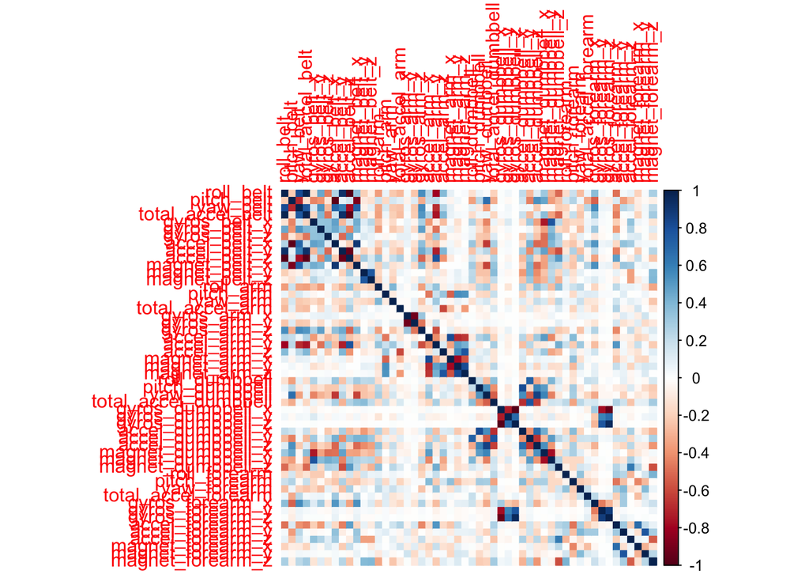

```r
corrPlot <- cor(train[, -length(names(train))])
corrplot(corrPlot, method="color")
```

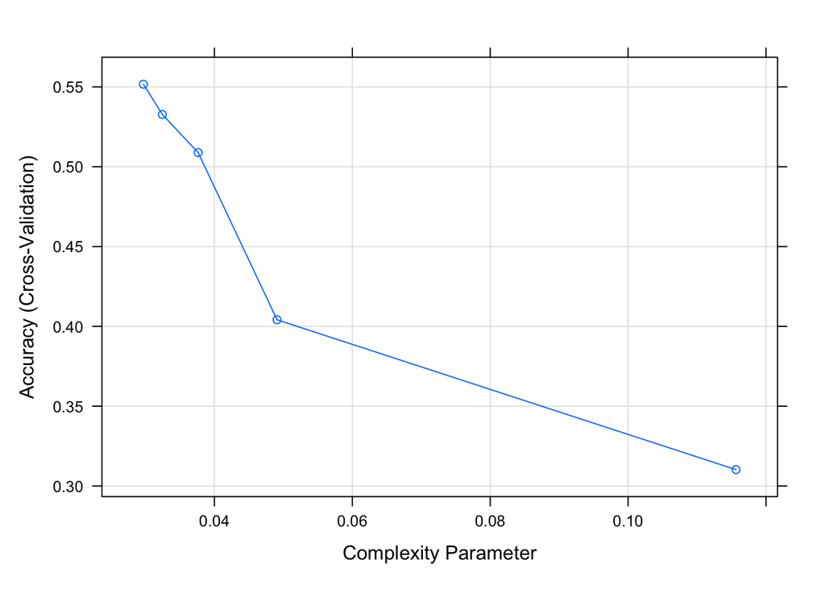

```r
plot(mod_trees)
```

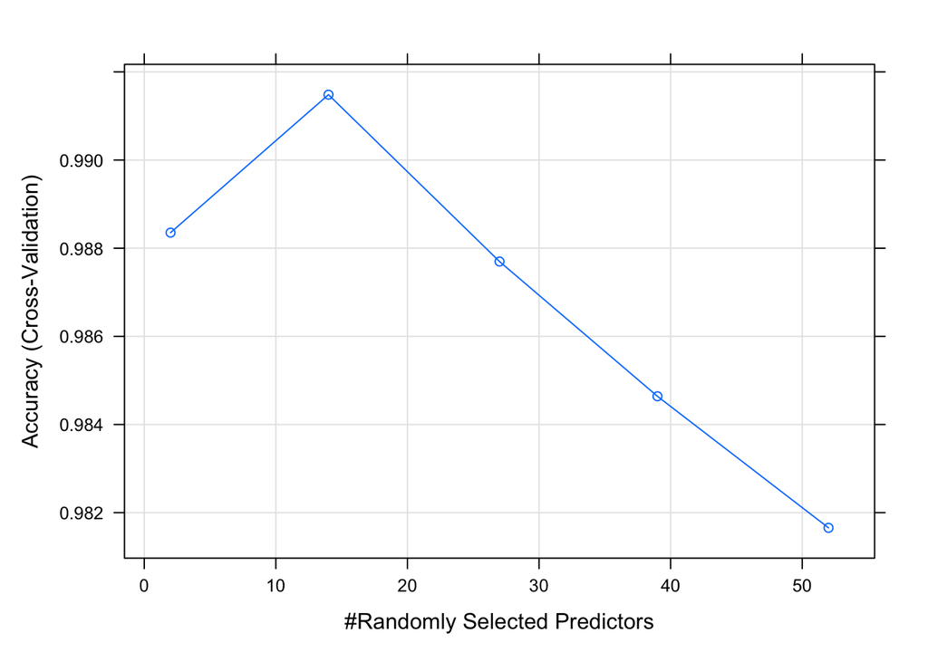

```r
plot(mod_rf)
```

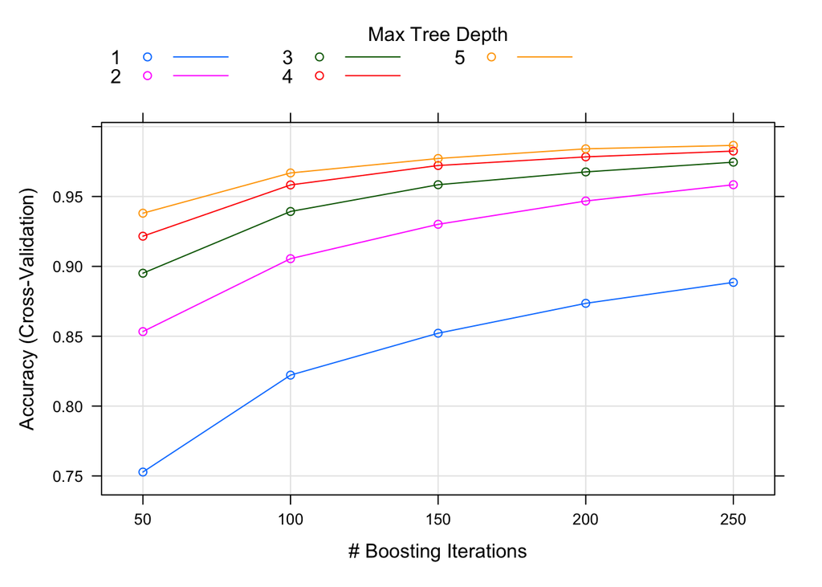

```r
plot(mod_gbm)
```